# Load Dataset

```
    solve science problems and conduct experiments are more positively correlated with science %
```

```python
soc.corr()
```

|  | Social % | Private tuition | Use Internet | Father edu | SocSci is difficult | Participate in SocSci | Express SocSci views | Historical excursions | Small groups in SocSci | Mother edu | Like school | Library use | Help in Study | Watch TV |
| --- | --- | --- | --- | --- | --- | --- | --- | --- | --- | --- | --- | --- | --- | --- |
| Social % | 1.000000 | 0.010595 | 0.026097 | 0.042762 | -0.014660 | 0.033194 | 0.038367 | 0.025969 | 0.033106 | 0.030971 | 0.015089 | 0.026521 | 0.008795 | 0.018712 |
| Private tuition | 0.010595 | 1.000000 | 0.065414 | 0.090460 | 0.031970 | 0.001554 | 0.027529 | 0.017535 | 0.003816 | 0.063373 | 0.084516 | 0.025188 | 0.210605 | 0.041081 |
| Use Internet | 0.026097 | 0.065414 | 1.000000 | 0.098187 | -0.004976 | 0.048034 | 0.062944 | 0.045219 | 0.056276 | 0.123527 | 0.053807 | 0.091459 | 0.074930 | 0.077732 |
| Father edu | 0.042762 | 0.090460 | 0.098187 | 1.000000 | -0.039061 | 0.045846 | 0.047718 | 0.068595 | 0.035127 | 0.504731 | 0.055673 | 0.031682 | 0.117538 | 0.081405 |
| SocSci is difficult | -0.014660 | 0.031970 | -0.004976 | -0.039061 | 1.000000 | 0.056171 | 0.055578 | 0.071846 | 0.058463 | -0.033458 | 0.020712 | -0.037707 | 0.002433 | 0.061040 |
| Participate in SocSci | 0.033194 | 0.001554 | 0.048034 | 0.045846 | 0.056171 | 1.000000 | 0.431275 | 0.448800 | 0.427517 | 0.057016 | 0.114349 | 0.072833 | 0.102885 | 0.192778 |
| Express SocSci views | 0.038367 | 0.027529 | 0.062944 | 0.047718 | 0.055578 | 0.431275 | 1.000000 | 0.355031 | 0.502907 | 0.061360 | 0.095634 | 0.092266 | 0.107596 | 0.153686 |
| Historical excursions | 0.025969 | 0.017535 | 0.045219 | 0.068595 | 0.071846 | 0.448800 | 0.355031 | 1.000000 | 0.348492 | 0.070715 | 0.112446 | 0.048282 | 0.085147 | 0.183305 |
| Small groups in SocSci | 0.033106 | 0.003816 | 0.056276 | 0.035127 | 0.058463 | 0.427517 | 0.502907 | 0.348492 | 1.000000 | 0.052338 | 0.084554 | 0.120533 | 0.104119 | 0.151908 |
| Mother edu | 0.030971 | 0.063373 | 0.123527 | 0.504731 | -0.033458 | 0.057016 | 0.061360 | 0.070715 | 0.052338 | 1.000000 | 0.052624 | 0.063324 | 0.109846 | 0.107619 |
| Like school | 0.015089 | 0.084516 | 0.053807 | 0.055673 | 0.020712 | 0.114349 | 0.095634 | 0.112446 | 0.084554 | 0.052624 | 1.000000 | 0.089301 | 0.159844 | 0.093987 |
| Library use | 0.026521 | 0.025188 | 0.091459 | 0.031682 | -0.037707 | 0.072833 | 0.092266 | 0.048282 | 0.120533 | 0.063324 | 0.089301 | 1.000000 | 0.094066 | 0.066887 |
| Help in Study | 0.008795 | 0.210605 | 0.074930 | 0.117538 | 0.002433 | 0.102885 | 0.107596 | 0.085147 | 0.104119 | 0.109846 | 0.159844 | 0.094066 | 1.000000 | 0.113827 |
| Watch TV | 0.018712 | 0.041081 | 0.077732 | 0.081405 | 0.061040 | 0.192778 | 0.153686 | 0.183305 | 0.151908 | 0.107619 | 0.093987 | 0.066887 | 0.113827 | 1.000000 |

```python
read.corr()
```

|  | Reading % | Private tuition | Use Internet | Father edu | Mother edu | Read magazine | Answer English WB | Answer English aloud | Read other books | Dictionary to learn | English is difficult | Read English | Read a book | Like school | Library use | Help in Study | Watch TV |
| --- | --- | --- | --- | --- | --- | --- | --- | --- | --- | --- | --- | --- | --- | --- | --- | --- | --- |
| Reading % | 1.000000 | 0.027265 | 0.040785 | 0.081985 | 0.085723 | 0.049233 | 0.043466 | 0.044266 | 0.064046 | 0.030586 | -0.053624 | 0.027390 | 0.031617 | 0.032808 | 0.035346 | 0.030043 | 0.035357 |
| Private tuition | 0.027265 | 1.000000 | 0.065414 | 0.090460 | 0.063373 | 0.068444 | 0.036495 | 0.015335 | 0.073522 | 0.054075 | 0.075568 | 0.009653 | 0.073088 | 0.084516 | 0.025188 | 0.210605 | 0.041081 |
| Use Internet | 0.040785 | 0.065414 | 1.000000 | 0.098187 | 0.123527 | 0.114173 | 0.090200 | 0.073077 | 0.081364 | 0.034820 | -0.042432 | 0.067985 | 0.099086 | 0.053807 | 0.091459 | 0.074930 | 0.077732 |
| Father edu | 0.081985 | 0.090460 | 0.098187 | 1.000000 | 0.504731 | 0.103977 | 0.053022 | 0.051907 | 0.125127 | 0.044524 | -0.087515 | 0.018022 | 0.063093 | 0.055673 | 0.031682 | 0.117538 | 0.081405 |
| Mother edu | 0.085723 | 0.063373 | 0.123527 | 0.504731 | 1.000000 | 0.136985 | 0.074035 | 0.078349 | 0.122897 | 0.039777 | -0.094625 | 0.064087 | 0.089612 | 0.052624 | 0.063324 | 0.109846 | 0.107619 |
| Read magazine | 0.049233 | 0.068444 | 0.114173 | 0.103977 | 0.136985 | 1.000000 | 0.210593 | 0.172239 | 0.162238 | 0.137431 | -0.052810 | 0.149983 | 0.433871 | 0.069057 | 0.153140 | 0.173181 | 0.255647 |
| Answer English WB | 0.043466 | 0.036495 | 0.090200 | 0.053022 | 0.074035 | 0.210593 | 1.000000 | 0.433957 | 0.099375 | 0.273112 | -0.002214 | 0.312730 | 0.205783 | 0.107788 | 0.116360 | 0.129090 | 0.152190 |
| Answer English aloud | 0.044266 | 0.015335 | 0.073077 | 0.051907 | 0.078349 | 0.172239 | 0.433957 | 1.000000 | 0.078268 | 0.240120 | 0.011079 | 0.291768 | 0.177763 | 0.101329 | 0.090298 | 0.100594 | 0.133772 |
| Read other books | 0.064046 | 0.073522 | 0.081364 | 0.125127 | 0.122897 | 0.162238 | 0.099375 | 0.078268 | 1.000000 | 0.102643 | -0.057594 | 0.043167 | 0.157717 | 0.104958 | 0.078473 | 0.156155 | 0.081342 |
| Dictionary to learn | 0.030586 | 0.054075 | 0.034820 | 0.044524 | 0.039777 | 0.137431 | 0.273112 | 0.240120 | 0.102643 | 1.000000 | 0.099018 | 0.184851 | 0.124409 | 0.060690 | 0.042798 | 0.099458 | 0.069337 |
| English is difficult | -0.053624 | 0.075568 | -0.042432 | -0.087515 | -0.094625 | -0.052810 | -0.002214 | 0.011079 | -0.057594 | 0.099018 | 1.000000 | 0.054590 | -0.029512 | 0.005193 | -0.078509 | -0.003013 | -0.013051 |
| Read English | 0.027390 | 0.009653 | 0.067985 | 0.018022 | 0.064087 | 0.149983 | 0.312730 | 0.291768 | 0.043167 | 0.184851 | 0.054590 | 1.000000 | 0.136082 | 0.073190 | 0.099303 | 0.082305 | 0.105563 |
| Read a book | 0.031617 | 0.073088 | 0.099086 | 0.063093 | 0.089612 | 0.433871 | 0.205783 | 0.177763 | 0.157717 | 0.124409 | -0.029512 | 0.136082 | 1.000000 | 0.076937 | 0.147003 | 0.155837 | 0.254174 |
| Like school | 0.032808 | 0.084516 | 0.053807 | 0.055673 | 0.052624 | 0.069057 | 0.107788 | 0.101329 | 0.104958 | 0.060690 | 0.005193 | 0.073190 | 0.076937 | 1.000000 | 0.089301 | 0.159844 | 0.093987 |
| Library use | 0.035346 | 0.025188 | 0.091459 | 0.031682 | 0.063324 | 0.153140 | 0.116360 | 0.090298 | 0.078473 | 0.042798 | -0.078509 | 0.099303 | 0.147003 | 0.089301 | 1.000000 | 0.094066 | 0.066887 |
| Help in Study | 0.030043 | 0.210605 | 0.074930 | 0.117538 | 0.109846 | 0.173181 | 0.129090 | 0.100594 | 0.156155 | 0.099458 | -0.003013 | 0.082305 | 0.155837 | 0.159844 | 0.094066 | 1.000000 | 0.113827 |
| Watch TV | 0.035357 | 0.041081 | 0.077732 | 0.081405 | 0.107619 | 0.255647 | 0.152190 | 0.133772 | 0.081342 | 0.069337 | -0.013051 | 0.105563 | 0.254174 | 0.093987 | 0.066887 | 0.113827 | 1.000000 |

Read other books and read magazines are more positively correlated with reading %

Father Education and Mother Education are common important factors of all subjects. Educated parents ,reduce their wards to get low marks.

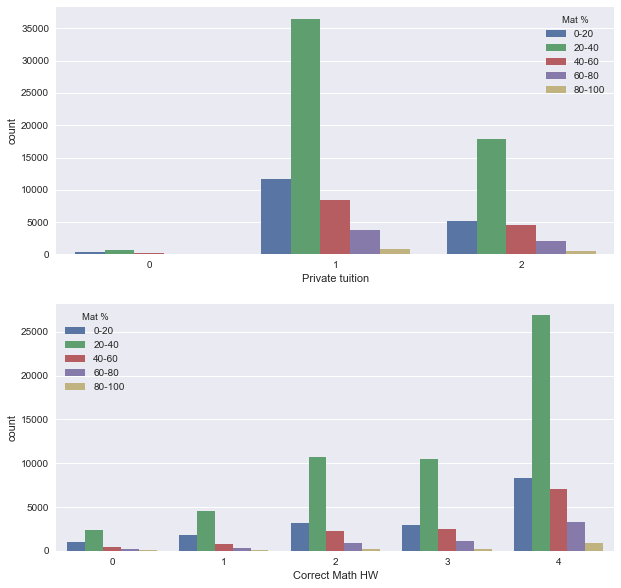

```python
# impact of private tuition and correcting maths hw on maths %
fig, (axis1, axis2)  = plt.subplots(2, 1,figsize=(10,10))
sns.countplot(x='Correct Math HW',hue='Mat %',data=df1,ax=axis2)
sns.countplot(x='Private tuition',hue="Mat %",data=df1,ax=axis1)
```

MATHS: Correct Maths HW regularly, gives good performance in students. Private tuition also improve the students performance. Mainly ,it reduces to get low marks. 1-No, 2-Yes.

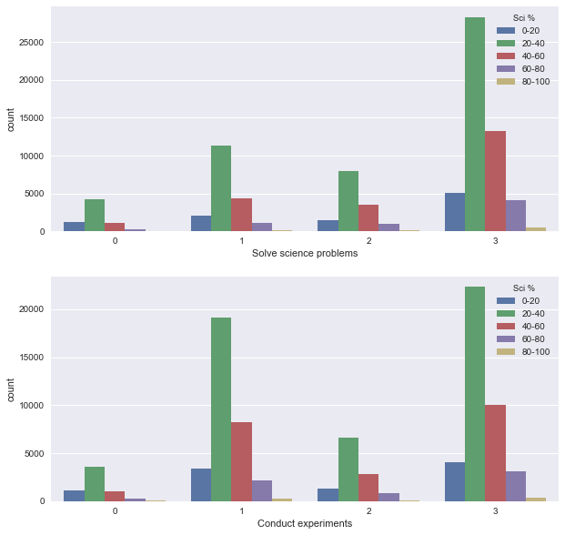

```python
# impact of solve science problems and conduct experiments on science %
fig, (axis1, axis2)  = plt.subplots(2, 1,figsize=(10,10))
sns.countplot(x='Solve science problems',hue='Sci %',data=df1,ax=axis1)
sns.countplot(x='Conduct experiments',hue='Sci %',data=df1,ax=axis2)
```

SCIENCE: Solve Science problems and conducting experiments , improve student performance in Science.

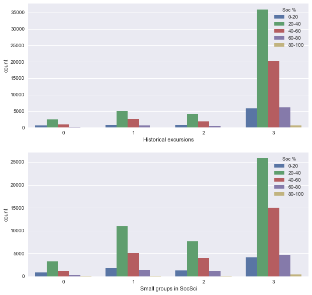

```python
# impact of Historical exccursions and group study on social %
fig, (axis1, axis2)  = plt.subplots(2, 1,figsize=(10,10))
sns.countplot(x='Historical excursions',hue="Soc %",data=df1,ax=axis1)
sns.countplot(x='Small groups in SocSci',hue='Soc %',data=df1,ax=axis2)
```

SOCIAL: Historical excursion and Group study increase students performance in Social.

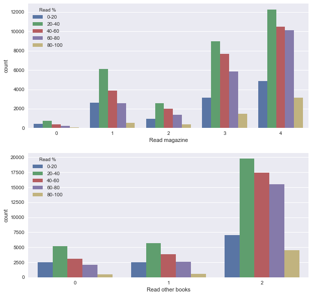

```python
# impact of Dictionary use and Reading other books habits on reading %
fig, (axis1, axis2)  = plt.subplots(2, 1,figsize=(10,10))
sns.countplot(x='Read magazine',hue="Read %",data=df1,ax=axis1)
sns.countplot(x='Read other books',hue="Read %",data=df1,ax=axis2)
```

READING Reading other books and using Read magazines habit gives more improvement to students in reasding %

states: South[AP,TN,KA,KL,PY,AN] West:[DN,DD,GA,MH,GJ] North:[DL,JK,RJ,HP,PB,UP,HR,UK,CH] East:[MG,MN,BR,MZ,OR,WB,SK,AR,TR,NG,JH]

```
                                BOYS AND GIRLS PERFORMANCE ACCORDING STATES
```

NUMBER OF STUDENTS (BOYS & GIRLS) IN STATE WISE. MORE STUDENTS FROM KERALA STATE.

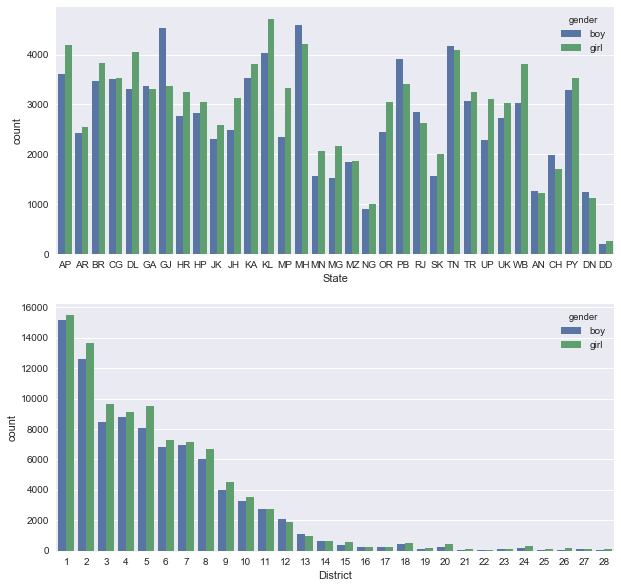

```python
# count the number of students by boys and girls
fig, (axis1, axis2)  = plt.subplots(2, 1,figsize=(10,10))
sns.countplot(x='State',hue='gender',data=df1,ax=axis1)
sns.countplot(x='District',hue='gender',data=df1,ax=axis2)
```

```python
# data for boys
boy=df1[df1.Gender == 1]
```

```python
# data for girls
girl=df1[df1.Gender == 2]
```

```python
# maths subject(State wise and state wise)
pd.crosstab([df1['gender'], df1['Mat %']],df1['state'],  margins=True)
```

| gender | state Mat % | east | north | south | west | All |
| --- | --- | --- | --- | --- | --- | --- |
| boy | 0-20 | 2050 | 2244 | 2081 | 1118 | 7493 |
|  | 20-40 | 6616 | 7582 | 6658 | 4528 | 25384 |
|  | 40-60 | 1843 | 1861 | 896 | 1040 | 5640 |
|  | 60-80 | 1028 | 833 | 306 | 338 | 2505 |
|  | 80-100 | 380 | 231 | 49 | 31 | 691 |
| girl | 0-20 | 2690 | 2698 | 2309 | 974 | 8671 |
|  | 20-40 | 7542 | 7723 | 7047 | 3944 | 26256 |
|  | 40-60 | 2172 | 1980 | 1159 | 1024 | 6335 |
|  | 60-80 | 1210 | 967 | 382 | 357 | 2916 |
|  | 80-100 | 351 | 271 | 65 | 30 | 717 |
| All |  | 25882 | 26390 | 20952 | 13384 | 86608 |